# Artificial Intelligence and Machine Learning

# A generative model on real data

```python
from sklearn.datasets import load_digits
digits = load_digits()
digits.data.shape
```

```
(1797, 64)
```

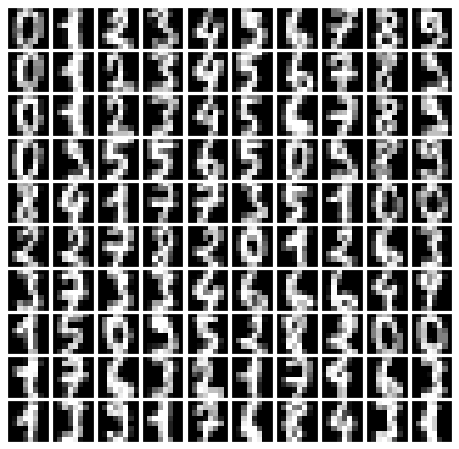

```python
def plot_digits(data):
    fig, ax = plt.subplots(10, 10, figsize=(8, 8),
                           subplot_kw=dict(xticks=[], yticks=[]))
    fig.subplots_adjust(hspace=0.05, wspace=0.05)
    for i, axi in enumerate(ax.flat):
        im = axi.imshow(data[i].reshape(8, 8), cmap='gray')
        im.set_clim(0, 16)
plot_digits(digits.data)
```

## The input dimension is D-64. We can try compress it for better speed

- We have nearly 1,800 digits in 64 dimensions, and we can build a GMM on top of these to generate more.
- GMMs can have difficulty converging in such a high dimensional space, so we will start with an invertible dimensionality reduction algorithm on the data.
- Here we will use a straightforward **PCA, asking it to preserve 99% of the variance in the projected data**

```python
from sklearn.decomposition import PCA
pca = PCA(0.99, whiten=False)
data = pca.fit_transform(digits.data)
data.shape
```

```
(1797, 41)
```

# 64 dimensiont to 41

- The result is 41 dimensions, a reduction of nearly 1/3 with almost no variance loss.
- Given this projected data, let's use the BIC to get a gauge for the number of GMM components we should use.

# Lets' now use BIC regularization to decide the number of components

- Note by doing this we have to run the algorithm for how many components we need to try.

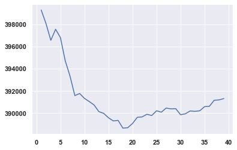

```python
n_components = np.arange(1, 40, 1)
models = [GaussianMixture(n, covariance_type='diag', random_state=0)
          for n in n_components]
aics = [model.fit(data).bic(data) for model in models]
plt.plot(n_components, aics);
```

# We will use 10 components (because we know we have 10 digits!)

# We could hope that each Gaussian model the digit class!

```python
idx = (n_components==10).nonzero()[0][0]
model = models[idx]
```

# Now let's generate (sample) 100 new data points

```python
data_new, y_new = model.sample(100)
data_new.shape
```

```
(100, 41)
```

# Now from subspace to the Input space

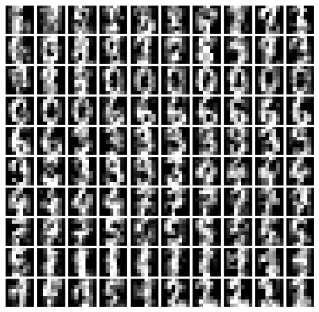

```python
digits_new = pca.inverse_transform(data_new)
plot_digits(digits_new)
```

# These digits *[should]* not exists in the initial dataset!

# GMM Model Debug

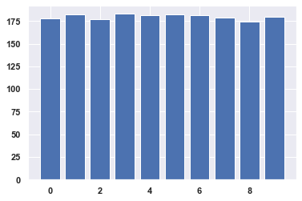

```python
plt.bar(*np.unique(digits.target, return_counts=True));
```

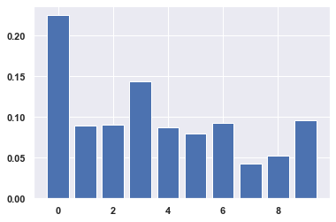

```python
plt.bar(range(10),model.weights_);
```

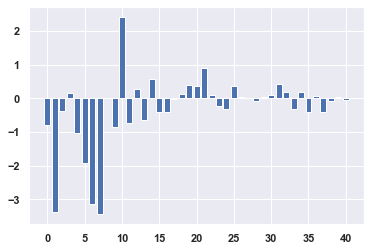

```python
plt.bar(range(model.means_[0].shape[0]),model.means_[0]);
```

# For example you can check if the mean is very close to a training point

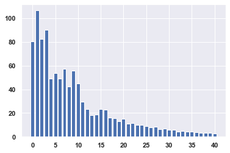

```python
plt.bar(range(model.means_[0].shape[0]),model.covariances_[0]);
```

# You could debug covariance to spot potential singularities (though sklearn may avoid that)

# Homework 3

- Fit a GMM "manually" using the labels provided by `digits.target` with `K=10`
- Fit now the same GMM without labels and debug/confront the parameters of the models
- Try to drawn some conclusions regarding the difference